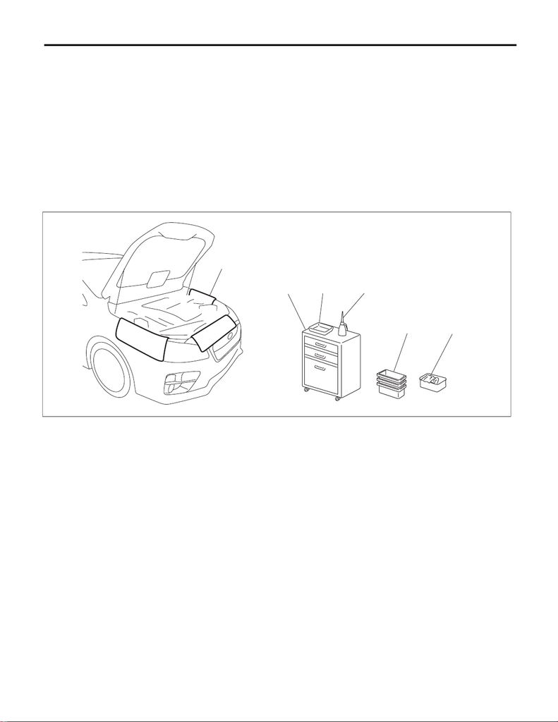

NT-2

Note

NOTE

1. Note

A: BASIC REPAIR HINT

This section describes basic points that the service operator must understand before performing the service

operation.

1. APPEARANCE

• Always wear clean work clothing.

• Wear a cap and protective shoes.

2. PROTECTION OF VEHICLE UNDER MAINTENANCE AND PREPARATION OF TOOLS/

EQUIPMENT

• Before work, cover the vehicle body. (Ex. grille cover, fender cover, seat cover and floor mat cover)

• Before performing the service operation, prepare tools, equipment, container box, grease and cloth etc.

3. SAFETY

• Before work, set the wheel stoppers to secure the vehicle.

• When performing work by multiple workers, call to each other to make sure that service operation is per-

formed safely.

• Ventilate the room when starting the engine.

• When performing the service operation of high-temperature parts like muffler, or rotating parts like fan and

other movable parts, be careful not to get burned or injured.

• For the jack-up and lift up, set the tool to the proper location to support the vehicle correctly. And use the

safety device properly when lifting up.

(1) Fender cover (3) Tray (5) Container box

(2) Tools/equipment case (4) Oil (6) Cloth

NT-00495

(4)(3)

(2)

(5)

(6)

(1)

15WRX_STI_US_EN.book 2 ページ ２０１５年２月１３日 金曜日 午前１１時２０分

[figure not shown]

NT-3

Note

NOTE

4. SERVICE OPERATION

• By identifying the vehicle problems thoroughly before service operation, diagnostics work will be per-

formed effectively.

• Before removing parts, confirm the installation condition or the damage of the parts.

• To reinstall parts properly, leave a note of the condition before work as necessary.

• For a part which needs positioning, take appropriate action such as putting alignment marks.

• For a removed part, clean it as necessary and check for damage and defect before installation. If a part is

damaged or does not work properly, replace it with a new part.

• Reconnect the harness connectors for each control module one or more minutes after disconnecting them.

• For installation of the bolt, nut, and screws, use tools suitable for each dimension, and use them vertically

and securely.

• Removing or installing the components or the connectors with the ignition switch ON will electrically impair

them.

5. REMOVED PART

• A removed part must be organized to avoid mixing up with similar parts. When same parts are used in mul-

tiple locations, such as pistons in engine, manage the parts by using labels with cylinder No. so that the parts

are not installed to the wrong location.

• Always replace nonreusable parts such as gasket and O-ring with new parts.

• After work, have a customer confirm the replaced part.

6. WHEN REMOVING BATTERY

When removing battery, power supply is cut off and the information stored in the computer memory is vola-

tilized. Therefore, setting information of some device is initialized to the factory default. The device and func-

tions initialized by removing battery are as follows.

No. Item Job contents when connecting battery

1 MFD Set to the date checked before disconnecting the battery.

2 Audio (settings that the customer set) Set to the contents checked before disconnecting the battery.

3 Navigation system (settings that the customer set)

• Time setting is not necessary because the time information is

received via GPS.

• Set the sound and other settings (items that were set in the

selection) to the contents checked before disconnecting the bat-

tery.

4

Temperature setting of fully automatic air conditioner

(settings that the customer set)

Set to the contents checked before disconnecting the battery.

5 Power window system

Initialize automatic full open/close of driver’s window (power win-

dow system). For the initialization procedure, refer to “GW” section.

<Ref. to GW-9, OPERATION, Power Window System.>

6 Steering lock system (model with keyless access)

If the engine does not start, initialize the steering lock system. For

the initialization procedure, refer to “KPS” section. <Ref. to

KPS(diag)-141, ENGINE DOES NOT START, INSPECTION, Diag-

nostics with Phenomenon.>

7 Electronic throttle system

Turn the ignition switch to ON, wait for 10 seconds or more, and

start the engine.

8 Engine control system

Let the engine run at idle until it fully warms up (the radiator fan

turns 2 times or more) under no electrical load condition.

9 Past trouble history (memory code) —

15WRX_STI_US_EN.book 3 ページ ２０１５年２月１３日 金曜日 午前１１時２０分

[figure not shown]

NT-4

Note

NOTE

7. OTHER ADJUSTMENT OPERATIONS BEFORE DELIVERING THE VEHICLE TO CUSTOM-

ER

Due to service and parts replacement convenience, perform the following operations before delivering the

vehicle to the customer.

B: NOTE

This information will improve the efficiency of maintenance and assure the sound work.

1. CLEANING

• Perform the operation in a clean location and use extra caution in dust proofing.

• Clean the items (except for assembly components) with steam, etc. before disassembly. During steam

cleaning, wrap the air breather, oil level gauge, connectors, etc. with vinyl tape to prevent steam from enter-

ing inside the parts.

• Use an appropriate cleaning solvent.

• Do not clean rubber parts such as O-ring, gasket and oil seal with cleaning solution.

2. FASTENERS NOTICE

Fasteners must be tightened to the specified torque.

Do not apply paint, lubricant, rust retardant or other substance to the surface around bolts, nuts, etc. Doing

so will cause such a malfunction as looseness of bolts and nuts, power change, etc. even if tightening the

bolts and nuts to the specified torque.

3. STATIC ELECTRICITY DAMAGE

Do not touch the control modules, connectors, logic boards and other such parts when there is a risk of static

electricity. Always use a static electricity prevention cord or touch grounded metal for the elimination of static

electricity before conducting work.

No. Item Check operation Adjustment operation

Additional adjustment operations

when replacing parts

1

Positions of devices

•Steering

• Room mirror

• Door mirror

• Seat

• Air conditioner vent grille

Is the device set to the

same position when the

vehicle was received from

the customer?

Adjust the device to the

similar position when the

vehicle was received from

the customer.

When removing/installing each

device

• Meter, instrument panel, steer-

ing column, etc.

• Room mirror, roof trim, sunroof

assembly, etc.

• Door mirror, door panel, etc.

• Seat, floor carpet, parking

brake lever, etc.

• Vent grille, instrument panel,

console box, etc.

2

Positions of switches

• SI-DRIVE

• Wiper, light (AUTO or

OFF)

• Headlight beam leveler

• Illumination control

• Room light

• Seat heater, etc.

Is the switch set to the

same position when the

vehicle was received from

the customer?

Set the switch to the same

position when the vehicle

was received from the

customer.

When removing/installing each

switch

15WRX_STI_US_EN.book 4 ページ ２０１５年２月１３日 金曜日 午前１１時２０分

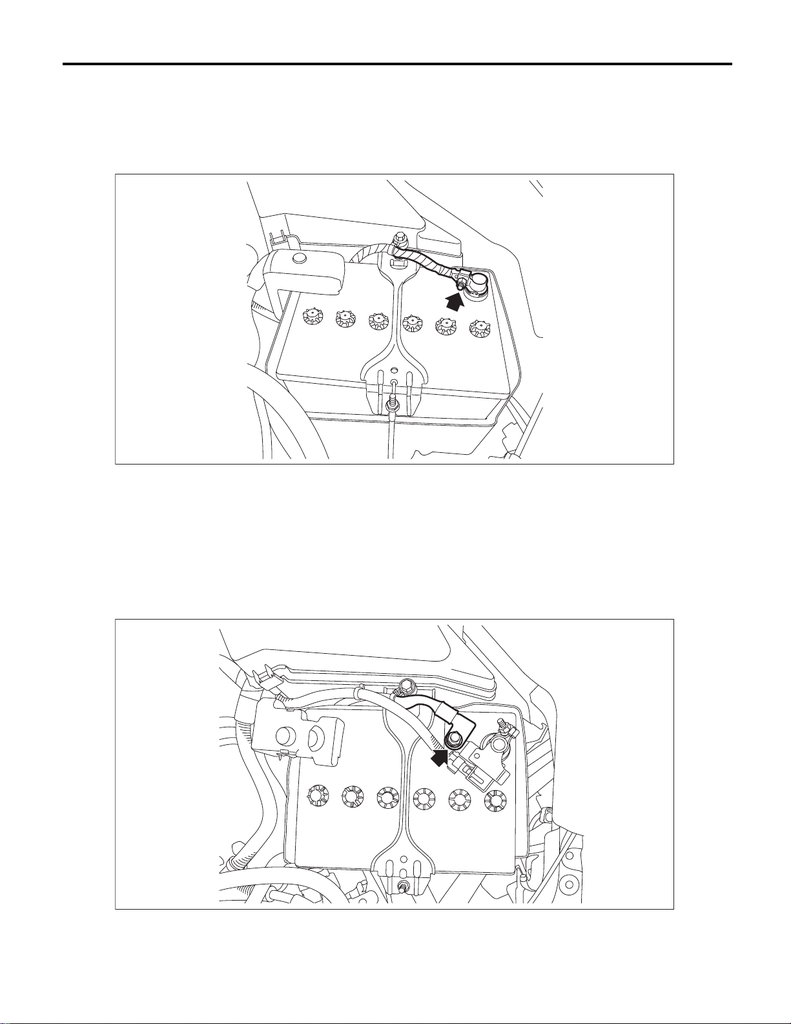

NT-5

Note

NOTE

4. BATTERY

When removing the battery terminal, always be sure to turn the ignition switch to OFF and disconnect the bat-

tery ground terminal first.

1: STI model

• Disconnect the ground cable from battery.

• Install in the reverse order of removal.

NOTE:

• Clean the battery cable terminals and apply grease to retard the formation of corrosion.

• Connect the positive (+) terminal, and then connect the negative (–) terminal of the battery.

• After the battery is installed, initial diagnosis of the electronic throttle control is performed. Wait for 10

seconds or more after turning the ignition switch to ON, and then start the engine.

2. Except for STI model

• Disconnect the ground terminal from battery sensor.

NT-00508

NT-00507

15WRX_STI_US_EN.book 5 ページ ２０１５年２月１３日 金曜日 午前１１時２０分

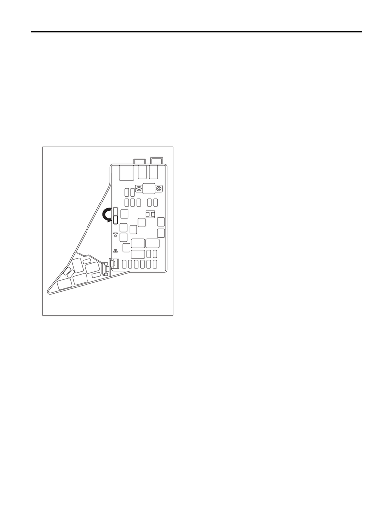

NT-6

Note

NOTE

• Install in the reverse order of removal.

NOTE:

• While holding the battery sensor by hand so that it does not rotate, install it.

• Clean the battery cable terminals and apply grease to retard the formation of corrosion.

• Connect the positive (+) terminal, and then connect the negative (–) terminal of the battery.

• After the battery is installed, initial diagnosis of the electronic throttle control is performed. Wait for 10

seconds or more after turning the ignition switch to ON, and then start the engine.

Tightening torque:

7.5 N·m (0.8 kgf-m, 5.5 ft-lb)

5. BACKUP/POWER SUPPLY FUSE

Backup fuse (20A) remains removed to prevent the battery consumption when vehicles are delivered. Install

the backup fuse by following the illustration.

6. IMMOBILIZER RELATED PART

Do not replace parts which have immobilizer ID with the parts from other vehicle.

• Model without keyless access function

All ignition keys, combination meter (except for C0), body integrated unit, ECM, security CM (for C0)

• Model with keyless access function

All access keys, keyless access CM, steering lock CM, ECM, ID code box (for C0)

7. SERVICE PARTS

Use genuine parts for maximum performance and maintenance when conducting repairs. Subaru/FHI will

not be responsible for poor performance resulting from the use of parts except for genuine parts.

8. PROTECTING VEHICLE UNDER MAINTENANCE

Make sure to attach the fender cover, seat covers, etc. before work.

9. ENSURING SECURITY DURING WORK

When working in a group of two or more, perform the work with calling each other to ensure mutual safety.

NT-00426

15WRX_STI_US_EN.book 6 ページ ２０１５年２月１３日 金曜日 午前１１時２０分

[figure not shown]

NT-7

Note

NOTE

10.LIFT AND JACK

When using a lift or shop jack to raise a vehicle or using rigid rack to support a vehicle, always follow instruc-

tions concerning jack-up points and weight limits to prevent the vehicle from falling, which could result in in-

jury. Be especially careful that the vehicle is balanced before raising it. Be sure to set the wheel stoppers

when jacking-up only the front or rear side of the vehicle.

CAUTION:

Select the lift attachment so that the spoiler assembly side does not contact the lift arm.

NOTE:

• When using a lift, follow its operation manual.

• When the spoiler assembly side contacts the lift arm, use a lift attachment.

• Do not work or leave unattended while the vehicle is supported with jack, support it with rigid racks.

• Be sure to use the rigid racks with rubber attached to cradle to support the vehicle.

• When using a lift, use an attachment or something similar.

• When using a plate lift, use a rubber attachment. Place the attachment to the specified position of the ve-

hicle, by adjusting front/rear and left/right sides accordingly.

• Align the cushion rubber center part of plate lift with the center part of rubber attachment.

• Do not use the plate lift whose attachment does not reach the supporting locations.

• Support locations

(A)

(B)

(C)

NT-00070

(A) 80 mm (3.1 in) or more

(B) 80 — 100 mm (3.15 — 3.94 in)

(C) 120 — 200 mm (4.72 — 7.87 in)

(1) Jack-up point

NT-00496

(1) (1)

15WRX_STI_US_EN.book 7 ページ ２０１５年２月１３日 金曜日 午前１１時２０分

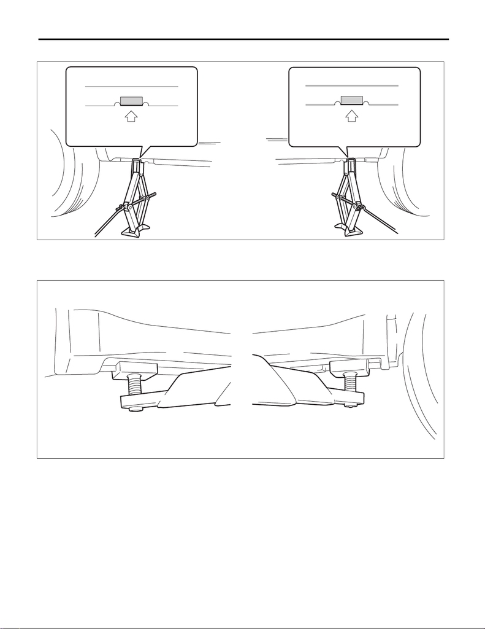

NT-8

Note

NOTE

• Pantograph jack

•Lift

CAUTION:

Depending on the type of the two-post lift, the spoiler assembly side may contact the arm. In such a

case, use the attachment of the regular option for the two-post lift.

(1) Jack-up point

(1)

NT-00459

(1)

NT-00271

15WRX_STI_US_EN.book 8 ページ ２０１５年２月１３日 金曜日 午前１１時２０分

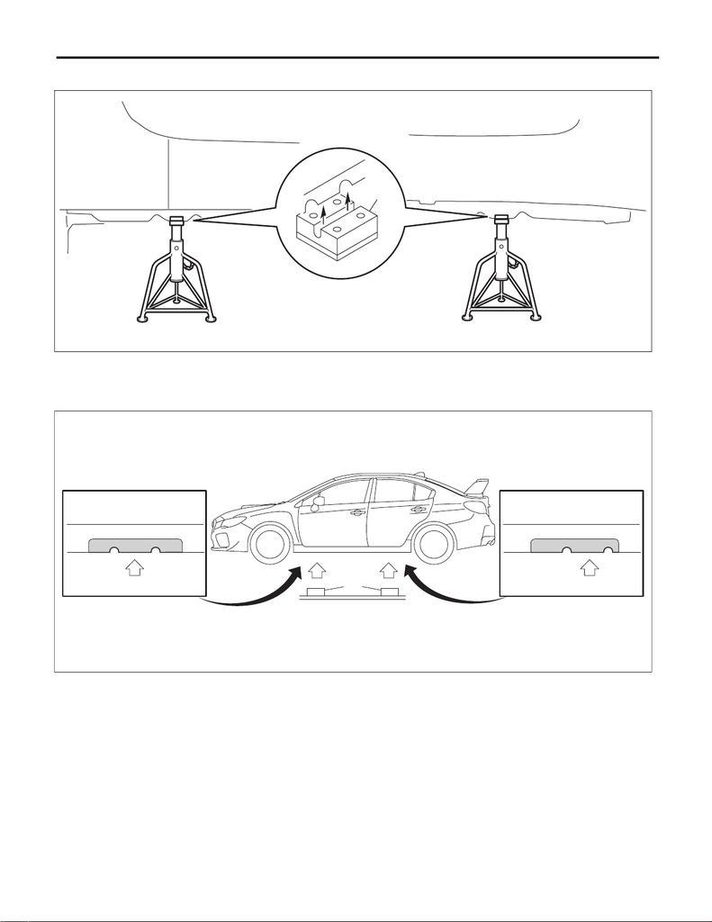

NT-9

Note

NOTE

• Rigid rack

• Plate lift

(A) Attachment

(1) Jack-up point (2) Attachment

NT-00242

(A)

NT-00497

(2)

(1)

(1)

15WRX_STI_US_EN.book 9 ページ ２０１５年２月１３日 金曜日 午前１１時２０分

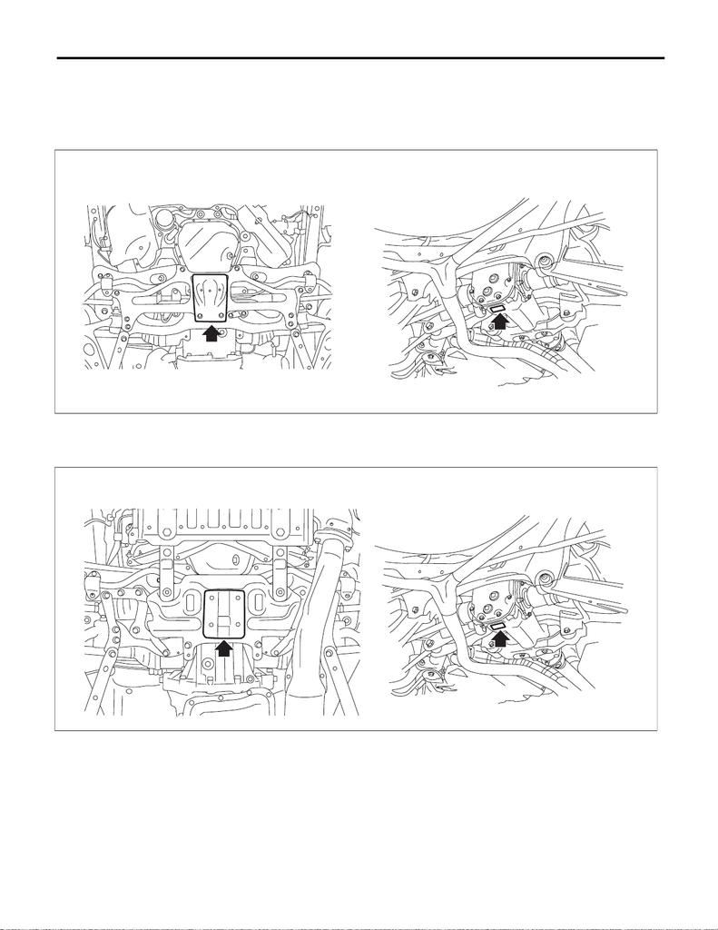

NT-10

Note

NOTE

• Jack-up point (when using a garage jack)

CAUTION:

If jacking up the front side of the vehicle, make sure that the jack is attached at the center of the jack-

up plate not at the sides.

STI model

Except for STI model

(A) Front (B) Rear

(A) Front (B) Rear

(B)(A)

NT-00499

(B)(A)

NT-00500

15WRX_STI_US_EN.book 10 ページ ２０１５年２月１３日 金曜日 午前１１時２０分

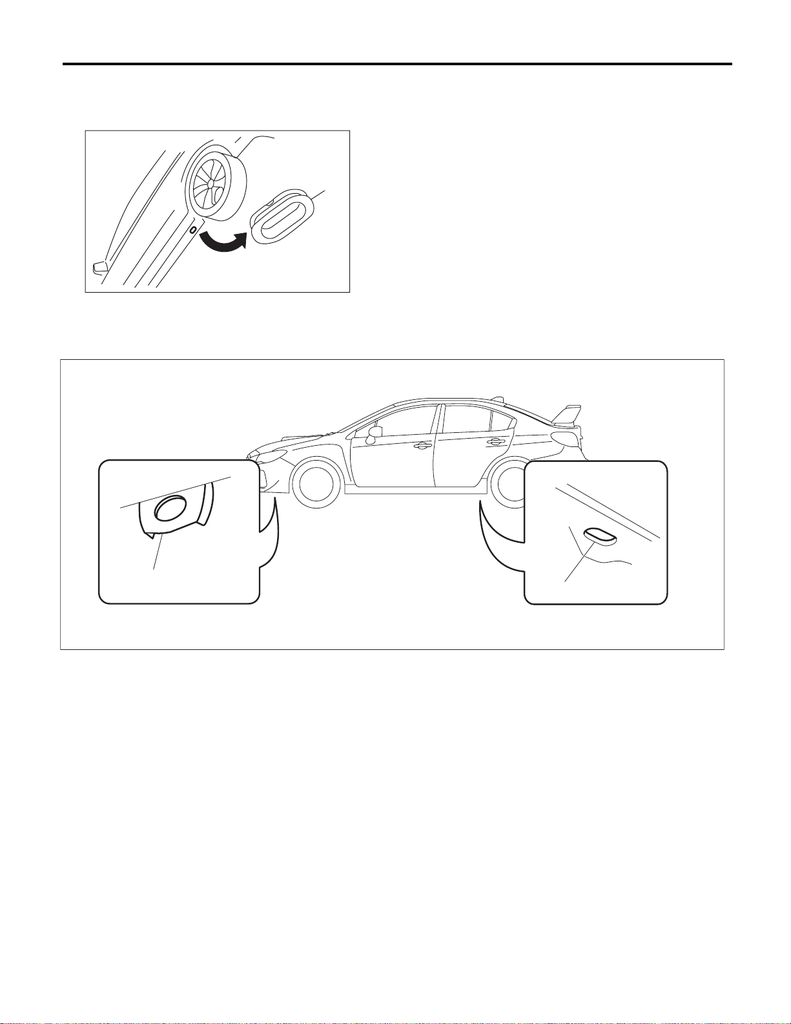

NT-11

Note

NOTE

11.TIE-DOWNS

Tie-downs are used when transporting vehicles and when using the chassis dynamo. Remove the grommet

of the tie-down hole and install the tie-down only to the specified locations on the vehicle.

• Tie-down location

NT-00486

(1)

(1) Grommet

(1) Hook for tie-down (2) Tie-down hole

NT-00498

(1)

(2)

15WRX_STI_US_EN.book 11 ページ ２０１５年２月１３日 金曜日 午前１１時２０分

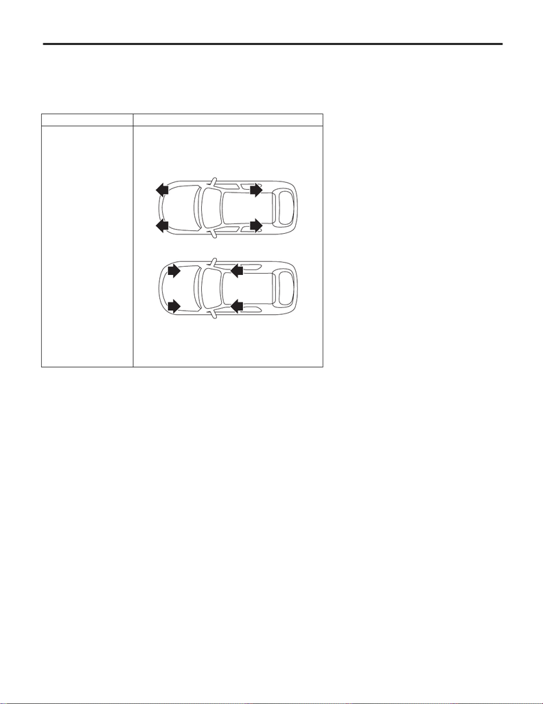

NT-12

Note

NOTE

• Chain direction at tie-down condition

CAUTION:

• Pull the front and rear of the vehicle in the opposite direction, and pull the left and right of the ve-

hicle in the same direction.

• Patterns except for the followings (recommended) are not allowed.

Recommended

Tie-down direction

NT-00214

15WRX_STI_US_EN.book 12 ページ ２０１５年２月１３日 金曜日 午前１１時２０分

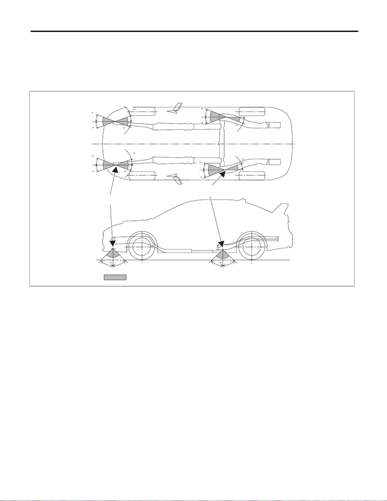

NT-13

Note

NOTE

• Tie-down range

For ground transportation

CAUTION:

When the vehicle is tied down from vehicle inside, hook the hooks of tie-down chain on the rear tie-

down holes from vehicle inside. When the vehicle is tied down from vehicle outside, hook the hooks

of tie-down chain on the rear tie-down hooks from vehicle outside.

(A) Front tie-down hook (B) Rear tie-down hole (C) Chain pulling range at tie-down

condition

NT-00502

45

45

:(C)

(A)

(B)

20

20

20

20

20

20

20

20

45

45

20

20

20

20

20

20

15WRX_STI_US_EN.book 13 ページ ２０１５年２月１３日 金曜日 午前１１時２０分

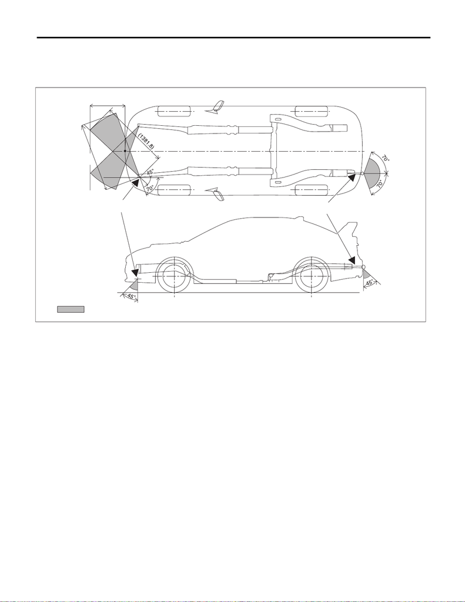

NT-14

Note

NOTE

For sea transportation

CAUTION:

The eyebolts are exclusively used for towing and sea transportation tie-down, and do not use them

for ground and freight transportation.

(A) Front tie-down hook (C) Chain pulling range at tie-down

condition

(B) Eyebolt (D) 400 mm (15.7 in)

NT-00509

(B)

(A)

(D)

:(C)

(E)

15WRX_STI_US_EN.book 14 ページ ２０１５年２月１３日 金曜日 午前１１時２０分

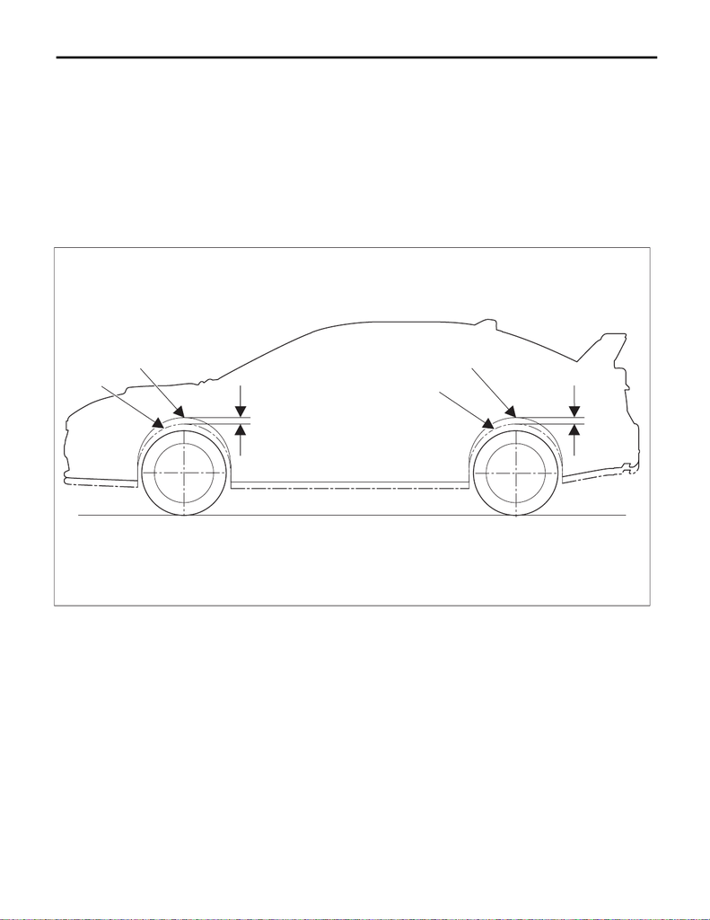

NT-15

Note

NOTE

• Vehicle sinking volume at tie-down condition

CAUTION:

The vehicle sinking volume at tie-down condition should be less than 50 mm (1.97 in) and make sure

to fix the vehicle securely.

Check to see if the tensions of chains or belts at tie-down condition are appropriate in the following

procedures.

1) Before tie-down, measure the distance between the highest tire point and highest arch point at the center

of wheel.

2) After tie-down, measure the distance between the highest tire point and highest arch point at the center of

wheel.

3) If the distance (A) between the measured value of 1) and 2) above, is less than 50 mm (1.97 in), it is judged

as OK. If the distance is 50 mm (1.97 in) or more, it is judged as NG because the tension is too high.

• Notes for the use of tie-down hook

When the vehicle is tied down from vehicle inside, hook the hooks of tie-down chain from vehicle inside, and

when the vehicle is tied down from vehicle outside, hook the hooks of tie-down chain from vehicle outside.

For front tie-down hook, use S hook and J hook, and for rear tie-down hole, use S hook, J hook and T hook.

T hook can be used only for rear tie-down hole.

(B) Arch position before tie-down (C) Arch position after tie-down

NT-00504

(A)

(B)

(C)

(A)

(B)

(C)

15WRX_STI_US_EN.book 15 ページ ２０１５年２月１３日 金曜日 午前１１時２０分

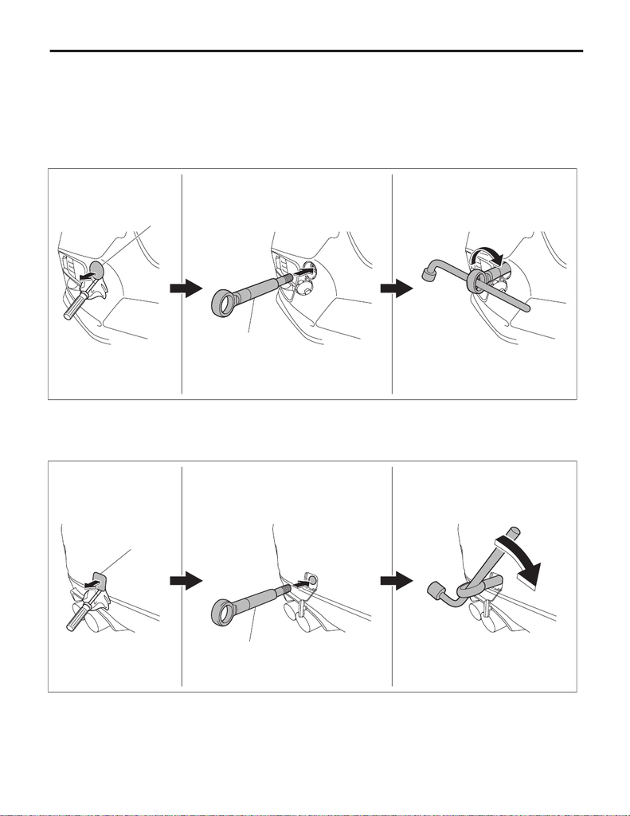

NT-16

Note

NOTE

12.TOWING

Avoid towing vehicles except when the vehicle cannot be driven. Use a loader instead of towing. When tow-

ing other vehicles, pay attention to the following to prevent hook or vehicle damage resulting from excessive

weight.

• Do not tow other vehicles with a front tie-down hook.

• Make sure the vehicle towing is heavier than the vehicle being towed.

•Front

Remove the hook cover, and install the towing hook (eyebolt).

• Rear

Remove the hook cover, and install the towing hook (eyebolt).

(A) Hook cover (B) Towing hook (eyebolt)

(A) Hook cover (B) Towing hook (eyebolt)

NT-00505

(B)

(A)

NT-00506

(B)

(A)

15WRX_STI_US_EN.book 16 ページ ２０１５年２月１３日 金曜日 午前１１時２０分

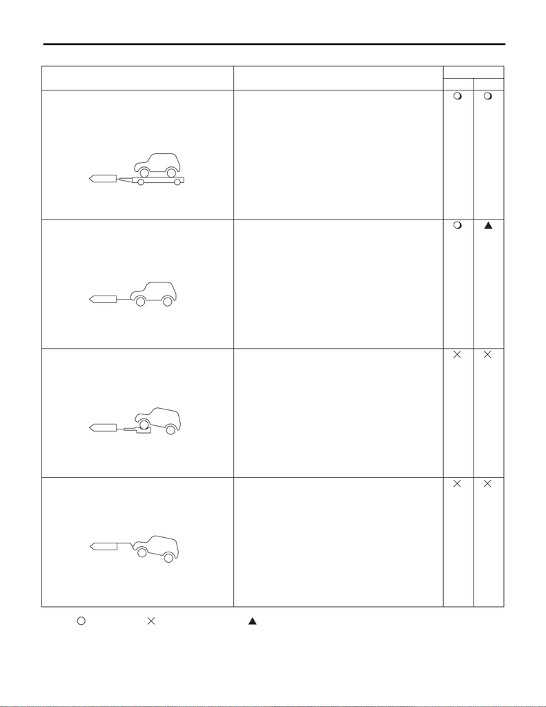

NT-17

Note

NOTE

• Precautions

Marked : OK, Marked : Prohibited, Marked : Conditionally OK

Towing Precautions

AWD

MT CVT

Lifting up four wheels (on a trailer) Towing the vehicle after lifting up all four wheels is a basic

rule for AWD model.

CAUTION:

When loading on a carrier transport, make sure to fol-

low the procedures for "LOADING ONTO CAR CARRI-

Rope • Check if both front and rear wheels are rotated nor-

mally.

• CVT model driving conditions: Driving speed of 30 km/h

(19 MPH) or less

Allow driving distance 50 km (31 miles) or less

Raising the front wheels Prohibited for full-time AWD model.

Lifting up the front wheels • Prohibited, due to damage on bumper, front grille, etc.

• Do not raise the vehicle with bumper.

NT-00023

NT-00024

NT-00025

NT-00026

15WRX_STI_US_EN.book 17 ページ ２０１５年２月１３日 金曜日 午前１１時２０分

[figure not shown]

NT-18

Note

NOTE

CAUTION:

• Place the shift lever in “N” position during towing.

• Do not lift up the rear wheels to avoid unsteady rotation.

• Turn the ignition key to “ACC”, then check the steering wheel moves freely. (Models without the

keyless access with push button start system)

• Turn the ignition switch to “ACC” or “ON” position, and check that the steering wheel moves

freely. (Models equipped with the keyless access with push button start system)

• Release the parking brake to avoid tire dragging.

• Since the power steering does not work, be careful for the heavy steering effort. (When engine

is stopped)

• Since the servo brake does not work, be careful that the brake is not applied effectively. (When

engine is stopped)

• In case of the malfunction of internal transmission or drive system, lift up four wheels (on a trail-

er) for towing.

• Do not use towing hook (eyebolt) except when towing.

• Make sure to detach the towing hook (eyebolt) after towing. If the hook remains attached, airbag

may not operate properly when receiving a shock from front side. And it may also affect the crash

performance of the vehicle.

• While being towed with all four wheels on the ground, turn the engine switch to ON but do not

start the engine.

15WRX_STI_US_EN.book 18 ページ ２０１５年２月１３日 金曜日 午前１１時２０分

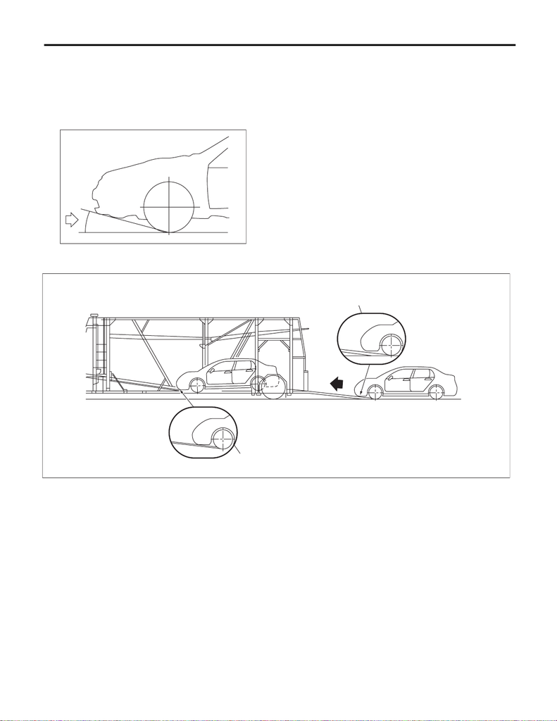

NT-19

Note

NOTE

13.LOADING ONTO CAR CARRIER TRUCK

When carrying the vehicle onto a car carrier truck, observe the following precautions.

CAUTION:

• When carrying the vehicle onto a car carrier truck, perform the operation being careful with the gap

between the height of the carrier’s floor and the vehicle lower side because of little clearance under

the front bumper.

• Use a supporting board (rubber) where the clearance is too small.

• Perform the operation being careful with the position shown in the figure below.

Before lowering the vehicle from the carrier car, perform the following operations.

CAUTION:

Always perform the following operations before lowering the vehicle from the carrier car. Otherwise,

the power unit will rotate reversely, which may cause the damage to the engine, vacuum pump, and

transmission.

1) Start the engine.

2) Set the transmission shift position into driving direction of the vehicle. (When the vehicle drives forward, do

not set the transmission into R range. When the vehicle drives rearward, do not set the transmission into 1

— 6 speed.)

CAUTION:

Be sure to perform 2) mentioned above even if the engine cannot be started in some reasons.

NT-00262

(1) Use a supporting board (rubber)

to ensure clearance from the

ramp.

(2) Before carrying the vehicle com-

pletely, lower the lower center floor

until it is level to make clearance.

NT-00263

(1)

(2)

15WRX_STI_US_EN.book 19 ページ ２０１５年２月１３日 金曜日 午前１１時２０分

[figure not shown]

NT-20

Note

NOTE

14.FRONT HOOD DAMPER STAY

1) Always perform works such as inspections and maintenance with both damper stays attached.

CAUTION:

At the inspection and general maintenance, do not detach the damper stays.

2) When wider hood opening is necessary, set the damper stay below as shown in the figure.

Tightening torque:

<Ref. to EB-2, FRONT HOOD, COMPONENT, General Description.>

CAUTION:

• The hood cannot be closed with the hood damper on the full open side. When it is necessary to

close, tie the hood striker and the radiator panel with a string etc. to fix them.

• After work, set the damper stays back to the normal position and tighten the bolts to the specified

torque.

15.GENERAL SCAN TOOL

Using general scan tools will greatly improve the efficiency of repairing engine electronic controls. Subaru

Select Monitor can be used to diagnose the engine, VDC, air conditioner and other electrically controlled

parts.

16.AWD CIRCUIT MEASURES

1) Full time AWD 6MT (STI model)

Since the driver’s control center differential (DCCD) is used in the center differential, cut-off of AWD circuit

cannot be carried out.

2) Full time AWD 6MT (except for STI model)

Since viscous coupling (limited slip differential) is used in the center differential, cut-off of AWD circuit cannot

be carried out.

3) Full-time AWD CVT model

Since VTD type is used in the center differential, cut-off of AWD circuit cannot be carried out.

(1) Normal attached position (2) Installation position at full open

(1)

(2)

NT-00501

15WRX_STI_US_EN.book 20 ページ ２０１５年２月１３日 金曜日 午前１１時２０分

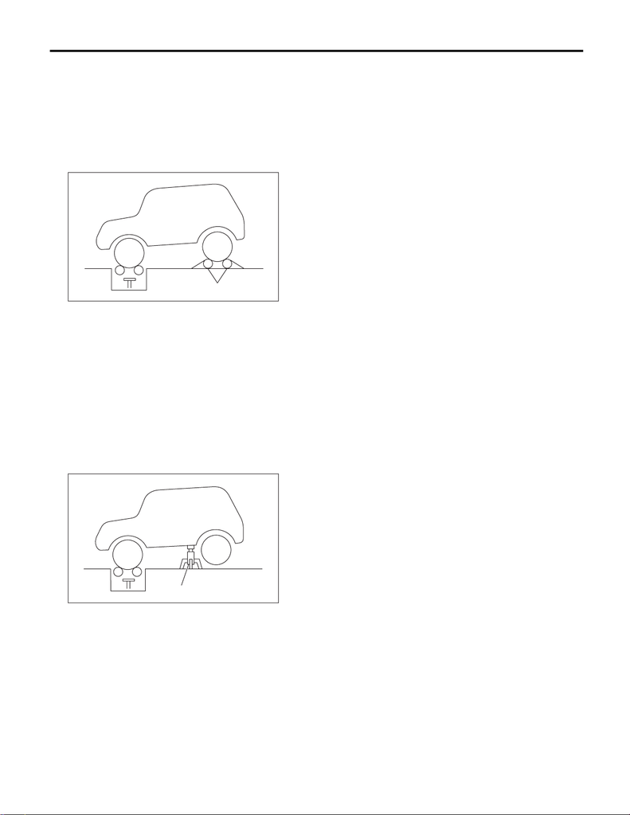

NT-21

Note

NOTE

17.SPEEDOMETER TEST

1) Rear wheel free roller system

(1) Set the free roller on the floor of rear wheel side securely according to the wheel base and rear tread

of the vehicle.

(2) Let the vehicle ride on the tester and free roller gently.

CAUTION:

Fix the vehicle using a pulling metal (chain or wire) to the front and rear towing hooks or tie-down

hook to prevent the lateral runout of front wheels and springing out of vehicle.

(3) Set the speedometer tester.

(4) Conduct the speedometer test work.

CAUTION:

Do not operate the clutch quickly and do not accelerate or decelerate suddenly during work.

2) Rear wheel jack-up system

(1) Set the vehicle on speedometer tester.

CAUTION:

Fix the vehicle using a pulling metal (chain or wire) to the front and rear towing hooks or tie-down

hook to prevent the lateral runout of front wheels and springing out of vehicle.

(2) Jack up the rear wheels and set the rigid racks to the specified locations of side sill.

(3) Conduct the speedometer test work.

CAUTION:

Do not operate the clutch quickly and do not accelerate or decelerate suddenly during work.

(A)

NT-00033

(A) Free roller

(A)

NT-00034

(A) Rigid rack

15WRX_STI_US_EN.book 21 ページ ２０１５年２月１３日 金曜日 午前１１時２０分

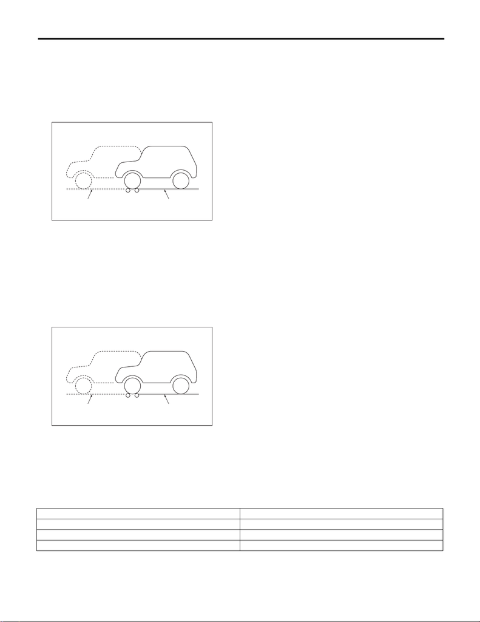

NT-22

Note

NOTE

18.BRAKE TEST

1) Full time AWD 6MT (except for STI model)

(1) Perform this test after driving the vehicle 2 to 3 km (1.24 to 1.86 miles) on road in order to stabilize the

viscous torque of viscous coupling.

(2) Keep the front or rear wheels on the ground for this test.

NOTE:

Effect of the viscous torque on braking force will be added approx. 25 kg compared with FWD model.

(3) When the brake dragging force is large.

• Check the dragging of brake pad or brake shoe.

• Since it may be affected by the viscosity of viscous coupling, jack up either of the front or rear two

wheels to check the each wheel rotation condition with the viscous coupling affection removed.

2) Full time AWD 6MT (STI model) and CVT model

(1) Keep the front or rear wheels on the ground during measurement.

(2) When the brake dragging force is large.

• Check the dragging of brake pad or brake shoe.

Specifications:

• When measurement is difficult to carry out because both of front wheels are locked, brake force mea-

surement in this condition conforms to standard grand total.

(C)

(A)

(B)

NT-00029

(A) Brake tester

(B) Position for measuring front wheel

(C) Position for measuring rear wheel

(C)

(A)

(B)

NT-00029

(A) Brake tester

(B) Position for measuring front wheel

(C) Position for measuring rear wheel

Braking force

Rear wheel total 10% or more of load on front or rear wheels

Difference between right and left wheels 8% or less of load on front or rear wheels

Grand total 50% or more of vehicle weight at the time of test

15WRX_STI_US_EN.book 22 ページ ２０１５年２月１３日 金曜日 午前１１時２０分

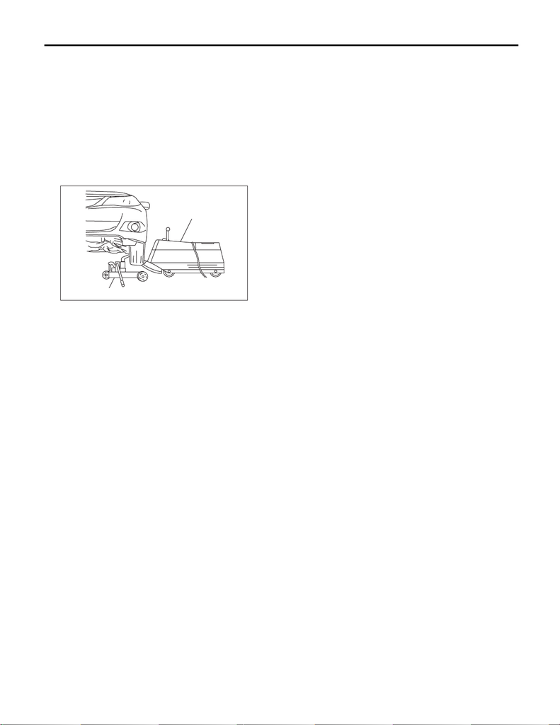

NT-23

Note

NOTE

19.ON THE CAR WHEEL BALANCING

CAUTION:

• Carry out the procedures after measuring the balance of each single tire.

• Set the vehicle so that the front and rear wheels are the same height.

• Make sure that the VDC is deactivated.

• Release the parking brake during measurement.

• Rotate each wheel by hands, and make sure it rotates without dragging.

• Do not operate the clutch quickly and do not accelerate or decelerate suddenly during work.

• When an error is indicated during engine drive, do not use the motor drive together.

1) Set the rigid rack to the specified locations of side sill, jack up the front or rear two wheels of non-measur-

ing side and set the pickup stands to two wheels of measuring side.

2) For drive wheel, drive the tires with engine for measurement.

3) For non-drive wheel, drive the tires from the on the car wheel balancer for measurement.

NT-00374

(A)

(B)

(A) Balancer body

(B) Pickup stand (left and right)

15WRX_STI_US_EN.book 23 ページ ２０１５年２月１３日 金曜日 午前１１時２０分

[figure not shown]

NT-24

Note

NOTE

15WRX_STI_US_EN.book 24 ページ ２０１５年２月１３日 金曜日 午前１１時２０分

[figure not shown]

IDENTIFICATION

ID

Page

1. Identification ...............................................................................................2

15WRX_STI_US_EN.book 1 ページ ２０１５年２月１３日 金曜日 午前１１時２０分